# Resampling Methods

10/1/2019

## Agenda

- Train-test split
- Cross-validation
- Bootstrap

## Train-test split

## Training and Test errors

Recall the distinction between the test error and the training error:

- The test error is the average error that results from using a statistical learning method to predict the response on a new observation, one that was not used in training the method
- In contrast, the training error can be easily calculated by applying the statistical learning method to the observations used in its training
- But the training error rate often is quite different from the test error rate, and in particular the former can dramatically underestimate the latter
- This problem is due to over-fitting: if we evaluate accuracy on the same data used to train the model we are cheating and the error estimate will be too optimistic

## How to assess model accuracy?

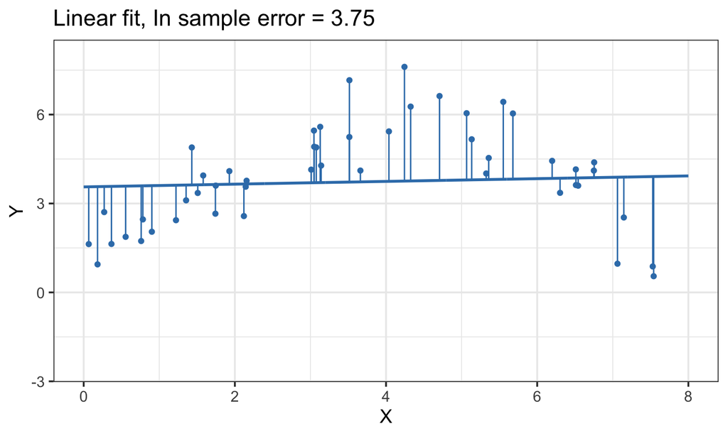

\[Y = \beta_0 + \beta_1 x\]

## How to assess model accuracy?

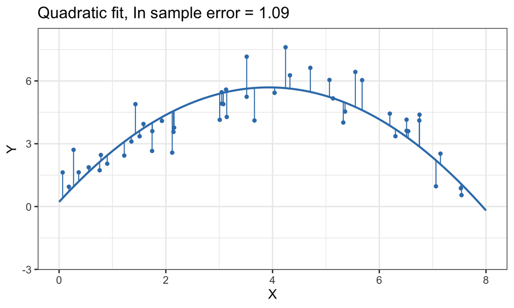

\[Y = \beta_0 + \beta_1 x + \beta_2 x^2\]

## How to assess model accuracy?

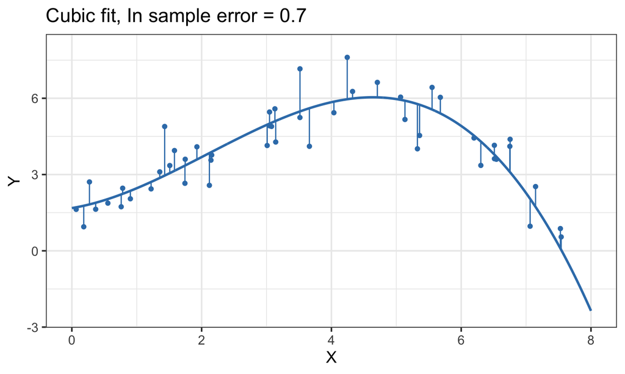

\[Y = \beta_0 + \beta_1 x + \beta_2 x^2 + \beta_3 x^3\]

## How to assess model accuracy?

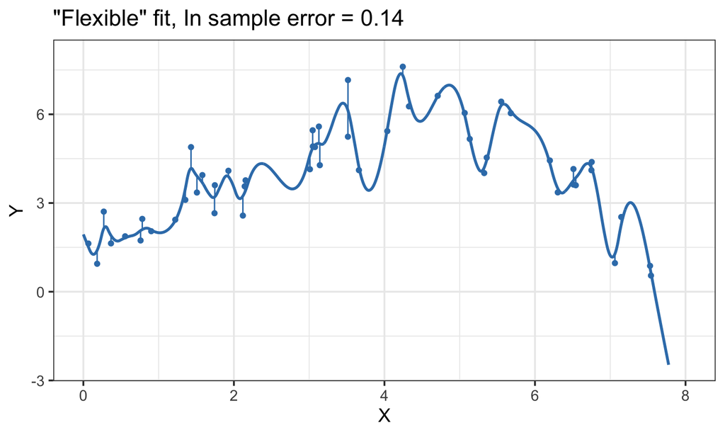

\[Y = ???\]

## How to assess model accuracy?

### What if I was hiding some test data?

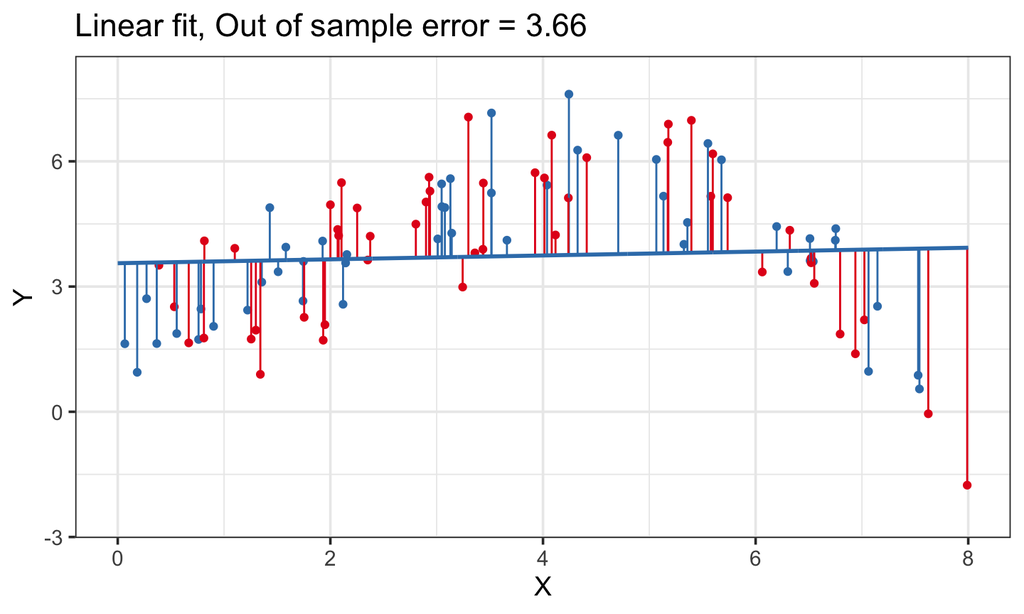

## How to assess model accuracy?

### What if I was hiding some test data?

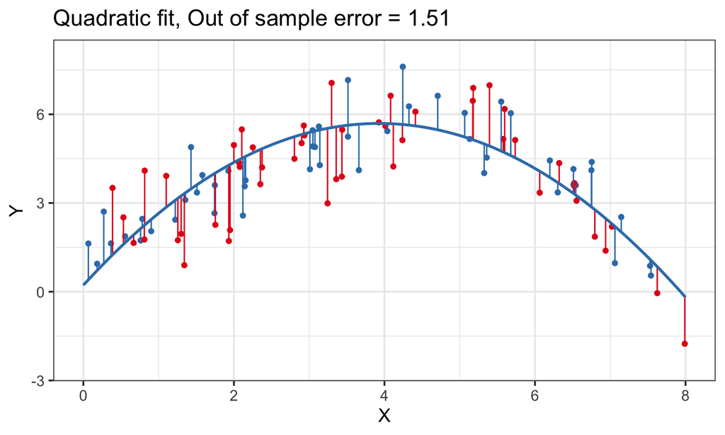

## How to assess model accuracy?

### What if I was hiding some test data?

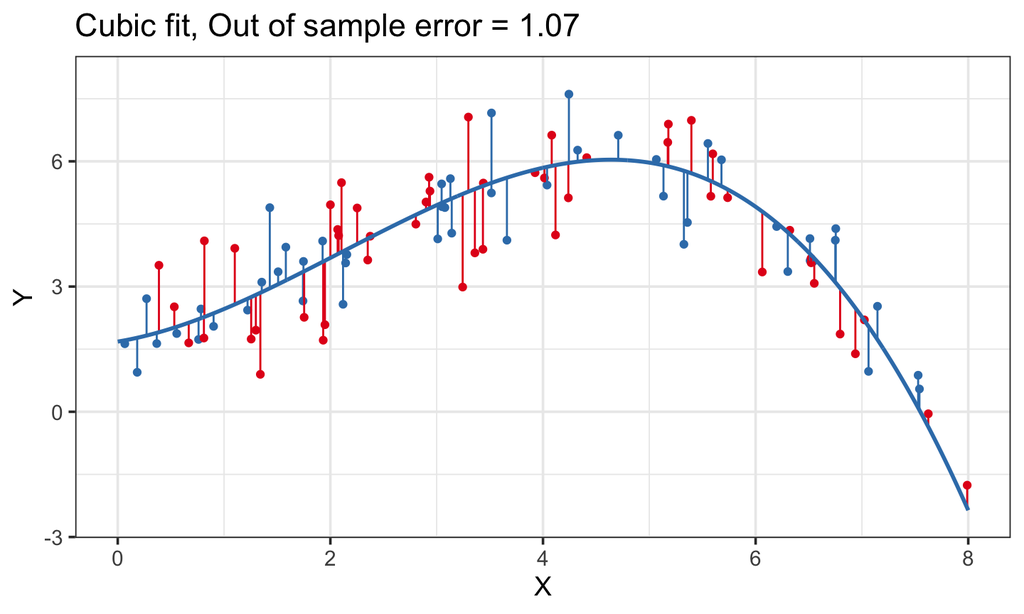

## How to assess model accuracy?

### What if I was hiding some test data?

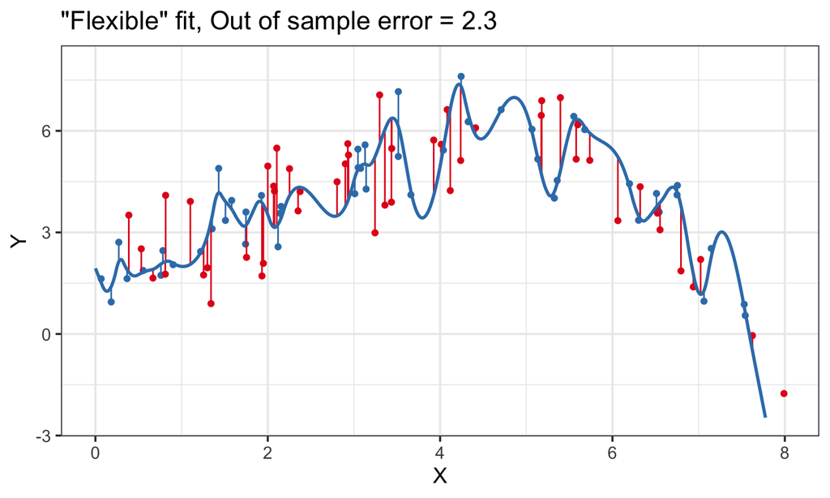

## Bias-variance tradeoff

[figure not shown]

## How to evaluate Test error

Ideal solution: have a large designated test set to evaluate performance. This is often not available!

- Some methods make a mathematical adjustment to the training error rate in order to estimate the test error rate. These include the \(C_p\) statistic, AIC and BIC (we will see these later in the course)
- Here we instead consider a class of methods that estimate the test error by holding out a subset of the training observations from the fitting process, and then applying the statistical learning method to those held out observations

## Validation set approach

So far we have evaluated accuracy with in-sample MSE (regression) and in-sample accuracy (classification).

**Goal**: estimate the prediction error of a fitted model.

A potential solution:

1. Randomly split the data into two parts: a training set and a test (validation, hold-out) set
2. Fit the model(s) on the training set
3. Make predictions on the test set using the fitted model(s)
4. Check how well you did (MSE, classification error, …)

A perfectly sensible approach, but it has still some drawbacks!

## Validation set approach

[figure not shown]

A random splitting into two halves: left part is training set, right part is validation set.

## Validation set approach

Drawback 1: the estimate of the error rate can be highly variable.

- It depends strongly on which observations end up in the training and testing sets
- Can be mitigated by averaging over multiple train/test splits, but this can get computationally expensive

Drawback 2: only some of the data points are used to fit the model.

- Statistical methods tend to perform worse with less data
- So the test-set error rate is biased: it tends to overestimate the error rate we would see if we trained on the full data set
- This effect is especially strong for complex models

## Validation set approach example

- We want to compare linear vs higher-order polynomial terms in a regression
- We randomly split the 392 observations into two sets, a training set containing 196 of the data points, and a validation set containing the remaining 196 observations

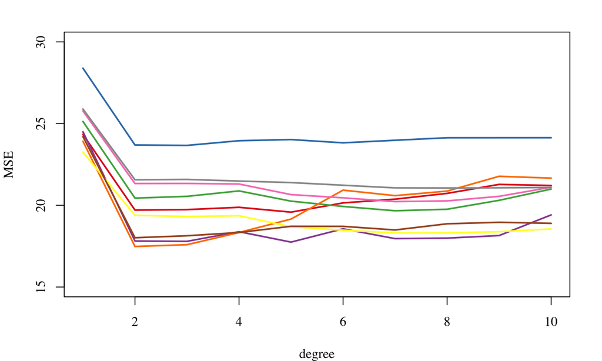

## Cross validation

## K fold Cross validation

It is a widely used approach for estimating test error.

Randomly divide the data into \(K\) equally sized parts (\(K\) non-overlapping groups, or folds).

For fold \(k \text { in } 1:K\)

1. Fit the model using all data points not in fold \(k\)
2. For all points \((y_i, x_i)\) in fold \(k\), predict \(\hat{y}_i\) using the fitted model
3. Calculate \(\text{Err}_k\), the average error on fold \(k\)

Estimate the error rate as:

\[CV_{(K)} = \frac{1}{K} \sum_{k=1}^K \text{Err}_k\]

## K fold Cross validation

- Choosing a large \(K\) requires more computation than choosing small \(K\) (the model has to be refit \(K\) times)
- More stable (lower variance) than running \(K\) random train/test splits
- Leave-one-out cross validation (LOOCV) is a special-case of \(K\)-fold CV with \(K = n\)

[figure not shown]

## Leave one out Cross validation

Key idea: average over all possible testing sets of size \(n_{test} = 1\).

For observations \(i \text { in } 1:n\)

1. Fit the model using all data points except \(i\)
2. Predict \(y_i\) with \(\hat{y}_i\), using the fitted model
3. Calculate the error, \(\text{Err}(y_i, \hat{y}_i)\)

Estimate the error rate as:

\[CV_{(n)} = \frac{1}{n} \sum_{k=1}^n \text{Err}(y_i, \hat{y}_i)\]

## Leave one out Cross validation

[figure not shown]

## Leave one out Cross validation

Less bias than the train/test split approach:

- fitting with \(n - 1\) points is almost the same as fitting with \(n\) points
- thus, LOOCV is less prone to overestimating the training-set error

No randomness:

- estimating the error rate using train/test splits will yield different results when applied repeatedly
- LOOCV will give the same result every time

Downside: must re-fit \(n\) times!

## Leave one out Cross validation

With least-squares linear or polynomial regression, an amazing shortcut makes the cost of LOOCV the same as that of a single model fit! The following formula holds

\[CV_{(n)} = \dfrac{1}{n} \sum_{i=1}^n \left( \dfrac{y_i - \hat{y}_i}{1 - h_i} \right)^2\]

where \(\hat{y}_i\) is the \(i^{th}\) fitted value from the original least squares fit, and \(h_i\) is the leverage.

## The bias-variance tradeoff (again)

Key insight: there is a bias-variance tradeoff in estimating test error.

Variance comes from overlap in the training sets:

- In LOOCV, we average the outputs of \(n\) fitted models, each trained on nearly identical observations
- In K-fold, we average the outputs of \(K\) fitted models that are less correlated, since they have less overlap in the training data. Generally it has less variance than LOOCV

Typical values: \(K = 5\) to \(K = 10\) (no theory; a purely empirical observation).

## Cross validation for Classification problems

We divide the data into \(K\) roughly equal-sized parts \(C_1, \dots, C_K\), where \(C_k\) denotes the indices of the observations in fold \(k\). There are \(n_k\) observations in fold \(k\): if \(n\) is a multiple of \(K\), then \(n_k = n/K\).

Compute \[CV_{(k)} = \frac{1}{K} \sum_{k=1}^K \text{Err}_k\] where \(\text{Err}_k = \sum_{i \in C_k} \mathcal{I}(y_i \neq \hat{y}_i)/n_k\).

## Cross-validation: right and wrong

Consider a simple binary classifier:

- Starting with \(5000\) predictors and \(50\) samples, find the \(100\) predictors having the largest correlation with the class labels
- We then apply a classifier such as logistic regression, using only these \(100\) predictors

How do we estimate the test set performance of this classifier? Can we apply cross-validation in step 2, forgetting about step 1?

## Cross-validation: right and wrong

This would ignore the fact that in Step 1, the procedure has already seen the labels of the training data, and made use of them. This is a form of training and must be included in the validation process.

- It is easy to simulate realistic data with the class labels independent of the outcome, so that true test error should be \(50\%\), but the CV error estimate that ignores Step 1 is zero! Try to do this yourself
- This error has made in many high profile genomics papers

## Cross-validation: wrong

[figure not shown]

## Cross-validation: right

[figure not shown]

## Example: k-NN for regression

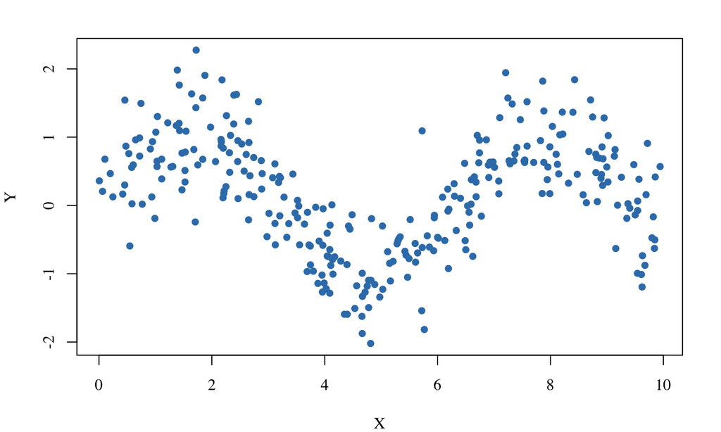

## Example: \(k = 1\)

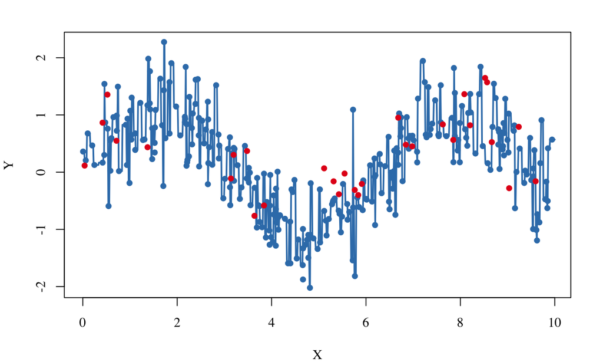

## Example: \(k = 50\)

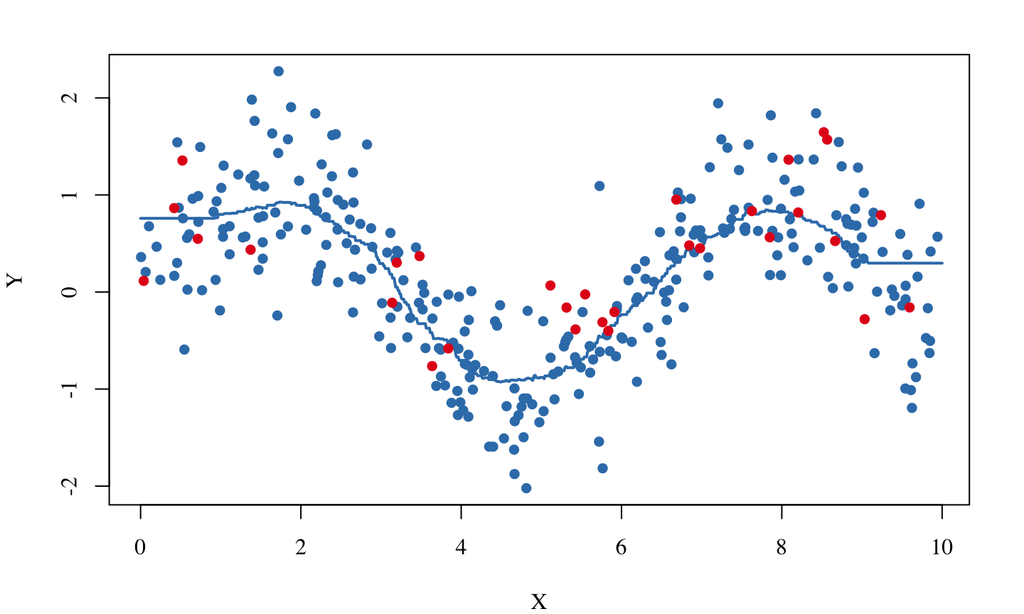

## Example: k-NN for regression

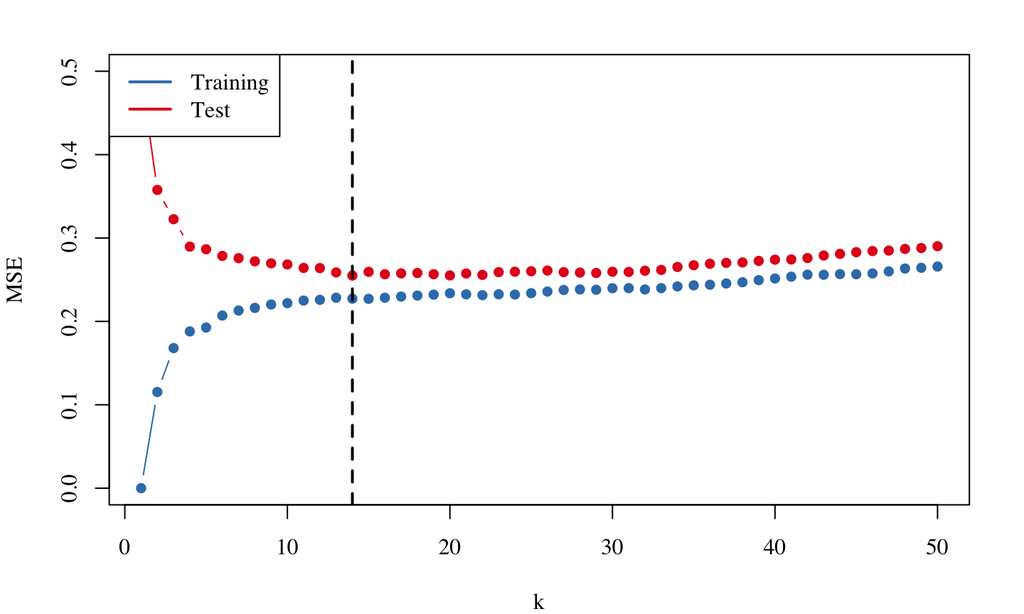

## Example: k-NN for regression

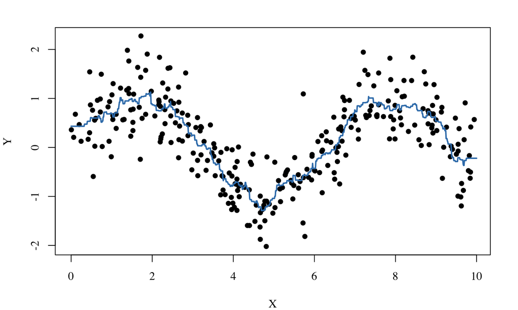

## The bootstrap

## The goal

- The bootstrap is a flexible and powerful statistical tool that can be used to quantify the **uncertainty** associated with a given estimator or statistical learning method
- For example, it can provide an estimate of the standard error of a coefficient, or a confidence interval for that coefficient
- It is not the same as the term “bootstrap” used in computer science meaning to “boot” a computer from a set of core instructions, though the derivation is similar

## Uncertainty quantification

Say that we have some data \(\mathbf{X} = (x_1, \dots, x_n)\) and we want to estimate the location parameter \(\mu\) via the classic estimator \(\overline{\mathbf{X}}\).

How can we quantify our uncertainty for this estimate?

Question: “how might my estimate \(\overline{\mathbf{X}}\) had been different if I had seen a different sample of \((x_i)\) pairs from the same population \(P(X)\)?”

## Algorithm

Bootstrap consists in the following algorithm:

For \(b\) in \(1:B\)

1. Construct a sample from \(\widehat{P}(X)\) (called a bootstrapped sample) by sampling \(n\) observations \(x_i\) **with replacement** from the original sample
2. Refit the model to each bootstrapped sample, giving you \(\overline{\mathbf{X}}^{(b)}\)

This gives us \(B\) draws from the bootstrapped sampling distribution of \(\overline{\mathbf{X}}\). Use these draws to form (approximate) confidence intervals and standard errors for \(\mu\).

Key: approximate \(P(X)\) with \(\widehat{P}(X)\)!

## A simple example

We have a sample from a normal distribution, and want to quantify uncertainty around the mean parameter.

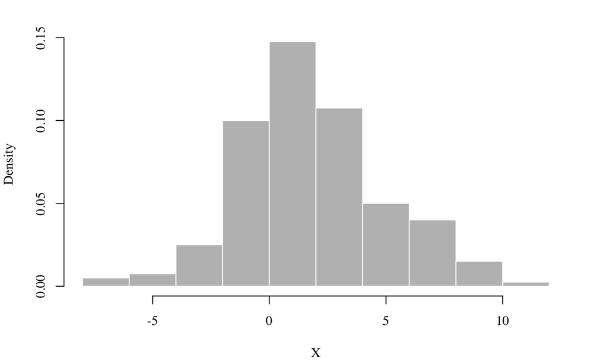

## A simple example

1. Sample \(n\) observations \((x_1^{(b)}, \dots, x_n^{(b)})\) **with replacement** from the original sample
2. Compute the mean \(\overline{X}^{(b)}\)

We then have a sample of estimates \((\overline{X}^{(1)}, \dots, \overline{X}^{(B)})\).

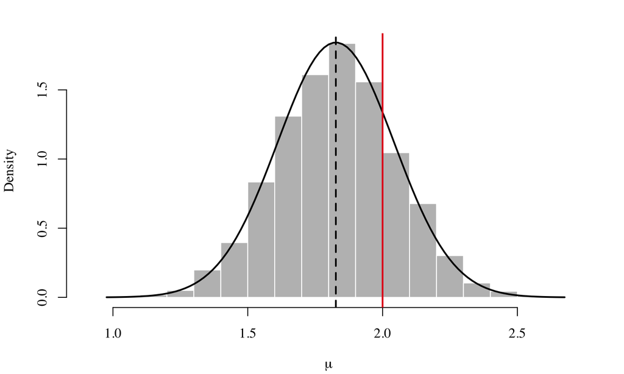

- We already knew the answer to this problem
- Bootstrap can be used for estimators whose sampling distribution is unknown (any estimator, any data distribution)

## More advanced bootstrap

- In more complex data situations, figuring out the appropriate way to generate bootstrap samples can require some thought
- For example, if the data is a time series, we cannot simply sample the observations with replacement (why?)
- We can instead create blocks of consecutive observations, and sample those with replacements. Then we paste together sampled blocks to obtain a bootstrap dataset

## Other uses of the bootstrap

- Primarily used to obtain standard errors of an estimate
- Also provides approximate confidence intervals for a population parameter
- Given a sample for the parameter of interest, we can construct an approximate \(95\%\) confidence interval for the true \(\mu\)
- This is called a Bootstrap Percentile confidence interval. It is the simplest method (among many approaches) for obtaining a confidence interval from the bootstrap